# Временные ряды

# Временные ряды:

- Одномерные.

Один показатель для каждого момента времени.

- Многомерные

Несколько показателей для каждого момента времени.

# Пример многомерного временного ряда

| Год | Население (тыс. чел.) | ВВП (млрд. руб.) |
| --- | --- | --- |
| 2002 | 145649 | 10830 |
| 2003 | 144964 | 13208 |
| 2004 | 144168 | 17027 |
| 2005 | 143474 | 21610 |
| 2006 | 142754 | 26917 |
| 2007 | 142220 | 33248 |
| 2008 | 141980 | 41277 |
| 2009 | 141900 | 38807 |
| 2010 | 142962 | 46308 |
| 2011 | 142914 | 55967 |
| 2012 | 143103 | 62176 |
| 2013 | 143395 | 66190 |

# Одномерный временной ряд

Временной ряд — последовательность случайных величин

$y_1, y_2, y_3, y_4 \ldots$

# Без предположений невозможно прогнозировать

1, 2, 3, 4, 5, ?

Какое число будет следующим?

# Без предположений невозможно прогнозировать

1, 2, 3, 4, 5, 42

# Базовое предположение — стационарность

Временной ряд называется стационарным, если:

- $E(y_1)=E(y_2)=E(y_3)=\ldots$
- $Var(y_1)=Var(y_2)=Var(y_3)=\ldots=\gamma_0$
- $Cov(y_1,y_2)=Cov(y_2,y_3)=Cov(y_3,y_4)=\ldots=\gamma_1$
- $Cov(y_1,y_3)=Cov(y_2,y_4)=Cov(y_3,y_5)=\ldots=\gamma_2$

# Предпосылки коротко:

Временной ряд называется стационарным, если:

- $E(y_t)=const$
- $Cov(y_t,y_{t-k})=\gamma_k$, т.е. не зависит от $t$

# Автоковариационная функция

$\gamma_k=Cov(y_t, y_{t-k})$ — (авто)-ковариационная функция процесса

# Самый простой пример — белый шум

Ряд $\e_t$ — белый шум, если:

- $E(\e_t)=0$
- $Var(\e_t)=\sigma^2$
- $Cov(\e_t,\e_{t-k})=0$

# Пример белого шума

$\e_t \sim N(0,4)$ и независимы

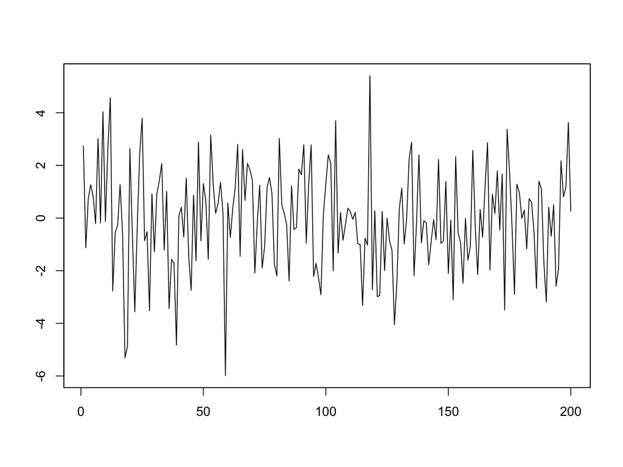

# Конвенция об обозначениях

На эту лекцию $\e_t$ всегда обозначает белый шум!

# Примеры нестационарных процессов

- Процесс с детерминистическим трендом
- Случайное блуждание

# Процесс с детерминистическим трендом

- $y_t= 5 + 6t + \e_t$. Нестационарность: $E(y_t)=5+6t\neq const$

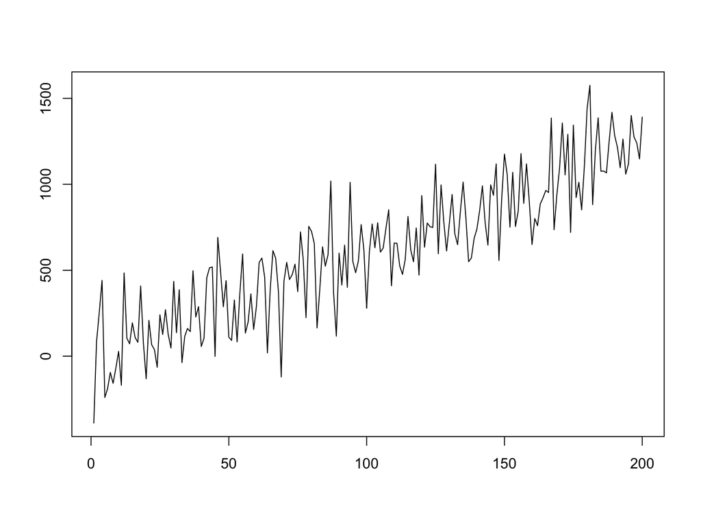

# Случайное блуждание

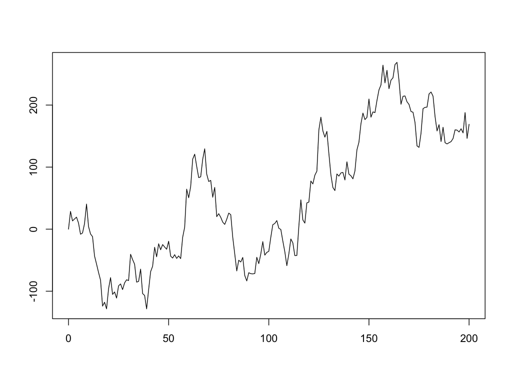

# Процесс скользящего среднего

Процесс представимый в виде

$y_t= \mu + \e_t + a_1 \e_{t-1} + \ldots + a_q \e_{t-q}$

# Обозначение процесса скользящего среднего

$y_t \sim MA(q)$, Moving Average

# Пример MA процесса [у доски]

$y_t = 5 + \e_t + 3 \e_{t-1} -2\e_{t-2}$

Найдите $E(y_t)$, $Var(y_t)$, $Cov(y_t,y_{t-k})$

# Запись с помощью оператора лага

$L$ — оператор лага:

- $Ly_t=y_{t-1}$
- $L\cdot L\cdot y_t=L^2y_t=y_{t-2}$

# Пример записи с помощью оператора лага

$MA(2):$

$y_t= 2 + \e_t + 3\e_{t-1}-2\e_{t-2}$

$y_t= 2 +(1+3L-2L^2)\e_t$

# Интерпретация:

Коэффициенты плохо интерпретируемы.

У стационарного процесса есть (авто)-корреляционная функция:

$\rho_k=Corr(y_t, y_{t-k})=\frac{Cov(y_t,y_{t-k})}{\sqrt{Var(y_t)Var(y_{t-k})}}=\frac{\gamma_k}{\gamma_0}$

# Интерпретация

Если $y_t$ — стационарный процесс и $y_t \sim N(\mu_y, \sigma^2_y)$, то:

$\rho_k$ — на сколько в среднем изменится $y_{t}$ при росте $y_{t-k}$ на единицу

# Автокорреляционная функция MA процесса [у доски]

$y_t = 5 + \e_t + 3 \e_{t-1} -2\e_{t-2}$

Найдите $\rho_k$

# Частная автокорреляционная функция-идея

$\rho_k$ — автокорреляционная функция. Измеряет совокупный эффект воздействия $y_{t-k}$ на $y_t$ как напрямую, так и через $y_{t-k+1}$, $y_{t-k+2}$, …, $y_{t-1}$

$\phi_k$ — частная автокорреляционная функция. Измеряет прямой эффект воздействия $y_{t-k}$ на $y_t$, устранив сквозное воздействие через $y_{t-k+1}$, $y_{t-k+2}$, …, $y_{t-1}$.

[figure not shown]

# Частная автокорреляционная функция-интерпретация

Если $y_t$ — стационарный процесс и $y_t \sim N(\mu_y, \sigma^2_y)$, то:

$\phi_k$ — на сколько в среднем изменится $y_{t}$ при росте $y_{t-k}$ на единицу

при фиксированных $y_{t-1}$, $y_{t-2}$, , $y_{t-k+1}$

# Частная автокорреляционная функция-определение

$\phi_{k}=Cor(y_t - P(y_t), y_{t-k} - P(y_{t-k}))$

где $P(y_t)$ — проекция случайной величины $y_t$ на линейную оболочку величин $y_{t-1}$, $y_{t-2}$, , $y_{t-k+1}$.

# Частная автокорреляция алгоритм подсчёта

$\gamma_0 \phi_1 = \gamma_1$

$\begin{cases} \gamma_0 *_1 + \gamma_1 \phi_2 = \gamma_1 \\ \gamma_1 *_1 + \gamma_0 \phi_2 = \gamma_2 \end{cases}$

$\begin{cases} \gamma_0 *_1 + \gamma_1 *_2 + \gamma_2 \phi_3 = \gamma_1 \\ \gamma_1 *_1 + \gamma_0 *_2 + \gamma_1 \phi_3 = \gamma_2 \\ \gamma_2 *_1 + \gamma_1 *_2 + \gamma_0 \phi_3 = \gamma_3 \end{cases}$

# Частная автокорреляционная функция MA процесса [у доски]

$y_t = 5 + \e_t + 3 \e_{t-1} -2\e_{t-2}$

Найдите $\phi_1$, $\phi_2$, $\phi_3$

# Процесс авторегрессии

- Стационарный процесс вида $y_t=c + b_1 y_{t-1} + b_2 y_{t-2} + \ldots + b_p y_{t-p} + \e_t$

# Обозначение процесса авторегрессии

$y_t \sim AR(p)$, AutoRegression

# Частная и обычная автокорреляционные функции для AR процесса [у доски]

$y_t = 2 + 0.5 y_{t-1} + \e_t \; \e_t \sim N(0,\sigma^2)$

Найдите $\rho_k$, $\phi_k$

# Альтернативная форма записи

$y_t = 2 + 0.5 y_{t-1} + \e_t$

Или

$(y_t - 4) = 0.5 (y_{t-1} - 4) + \e_t$

# Важное предупрежедение

Из одного уравнения $y_t = 2 + 0.5 y_{t-1} + \e_t$ не следует автоматически стационарность (!)

# Пример множества решений [у доски]

$y_t = 2 + 0.5 y_{t-1} + \e_t \; \e_t \sim N(0,1)$

# Подразумеваем стационарное решение

Пишем: $y_t = 2 + 0.5 y_{t-1} + \e_t \; \e_t \sim N(0,1)$

# AR процесс можно записать с помощью лага

$y_t=2+0.5y_{t-1}-0.06y_{t-2}+\e_t$

$(1-0.5L+0.06L^2)y_t=2+\e_t$

# Характеристический многочлен

$(1-0.5L+0.06L^2)y_t=2+\e_t$

$f(L)y_t=2+\e_t$

$f(L)$ — характеристический многочлен

# Когда у есть стационарное решение?

$f(L)y_t=c+\e_t$

Если корни характеристического уравнения AR процесса, $f(z)=0$, по модулю больше единицы, то существует единственное стационарное решение, в котором $y_t$ выражается через прошлые шумы, то есть через $\e_t$, $\e_{t-1}$, $\e_{t-2}$,

# Упражнение [у доски]

Пример 1. $y_t=7+0.5y_{t-1}-0.06y_{t-2}+\e_t$

Пример 2. $y_t=-3+1.2y_{t-1}-0.2y_{t-2}+\e_t$

Есть ли у этих уравнений стационарные решения?

# Прогнозирование

Прогноз на $h$ шагов вперед: $E(y_{t+h}|y_t, y_{t-1}, y_{t-2}, \ldots)$

Часто кратко обозначают: $\hat{y}_{t+h}$

# Упражнение на прогнозирование [у доски]

$y_t=2+0.5y_{t-1}-0.06y_{t-2}+\e_t \; \e_t \sim N(0;4)$

$y_{100}=4$, $y_{99}=3$.

Постройте точечный и интервальный прогноз на 1 и 2 шага вперед

# Модель авторегрессии и скользящего среднего

# Обозначение

- $y_t \sim ARMA(p,q)$

# Сумма $p+q$ минимально возможная

- $y_t=\e_t$
- $y_t-y_{t-1}=\e_t-\e_{t-1}$

В этом примере $y_t \sim ARMA(0,0)$

# ARMA — это наше всё!

Теорема.

Любой стационарный процесс можно представить в виде $MA(\infty)$

Практический вывод. С помощью $ARMA(p,q)$ можно компактно и сколь угодно точно описать любой стационарный процесс

# Итого про ARMA(p,q)

- коэффициенты не интерпретируемы
- используются для прогнозирования

# Оценивание коэффициентов

Есть $T$ наблюдений: $y_1$, $y_2$, $y_3$, , $y_T$

Чаще всего используется метод максимального правдоподобия

# Подробности метода максимального правдоподобия

- Как правило, предполагается нормальность $\e_t \sim N(0;\sigma^2)$
- Стационарность $y_t$

# Результат метода максимального правдоподобия

На выходе получаем оценки

$\hat{\theta}=(\hat{c}, \hat{a}_1, \ldots, \hat{a}_q, \hat{b}_1, \ldots, \hat{b}_q, \hat{\sigma}^2)$

И оценку их ковариационной матрицы $\widehat{Var}(\hat{\theta})$

# Проверка гипотез и доверительные интервалы

$\frac{\hat{a}_j - a_j}{se(\hat{a}_j)} \to N(0;1)$

# Выборочная автокорреляционная функция

ACF — autocorrelation function

$\hat{\rho}_k = \frac{\sum_{t=k+1}^{T} (y_t-\bar{y})(y_{t-k}-\bar{y})}{\sum_{t=1}^{T} (y_t-\bar{y})^2}$

# Выборочная частная автокорреляционная функция

PACF — partial autocorrelation function

Получим $\hat{\phi}_k$ из оценки регрессии

$\hat{y}_t = * + * \cdot y_{t-1} + * \cdot y_{t-2} + \ldots + * \cdot y _{t-k+1} + \phi_k y_{t-k} + u_t$

# Примечания к расчету автокорреляционной функции

- Для оценки каждого $\hat{\phi}_k$ строится отдельная регрессия
- Из каждой регрессии нужен только последний коэффициент

# Алгоритм на практике

1. Графики ряда, ACF, PACF
2. Если ряд нестационарный, то преобразуем
3. Выбираем $p$ и $q$
4. Оцениваем $ARMA(p,q)$
5. Прогнозируем

# Основное преобразование

Взятие разности: переход от $y_t$ к $\Delta y_t$

# Обозначение

- $y_t \sim ARIMA(p,1,q)$ равносильно $\Delta y_t \sim ARMA(p,q)$
- $y_t \sim ARIMA(p,0,q)$ равносильно $y_t \sim ARMA(p,q)$

# Выбор $p$ и $q$ по графикам

График выборочной корреляционной функции есть даже у нестационарного процесса!

У нестационарного процесса $\rho_k$, $\phi_k$ не существуют, однако компьютер всегда может построить график выборочной автокорреляционной и выборочной частной автокорреляционной функции!

# Белый шум

Белый шум, $y_t=\e_t$

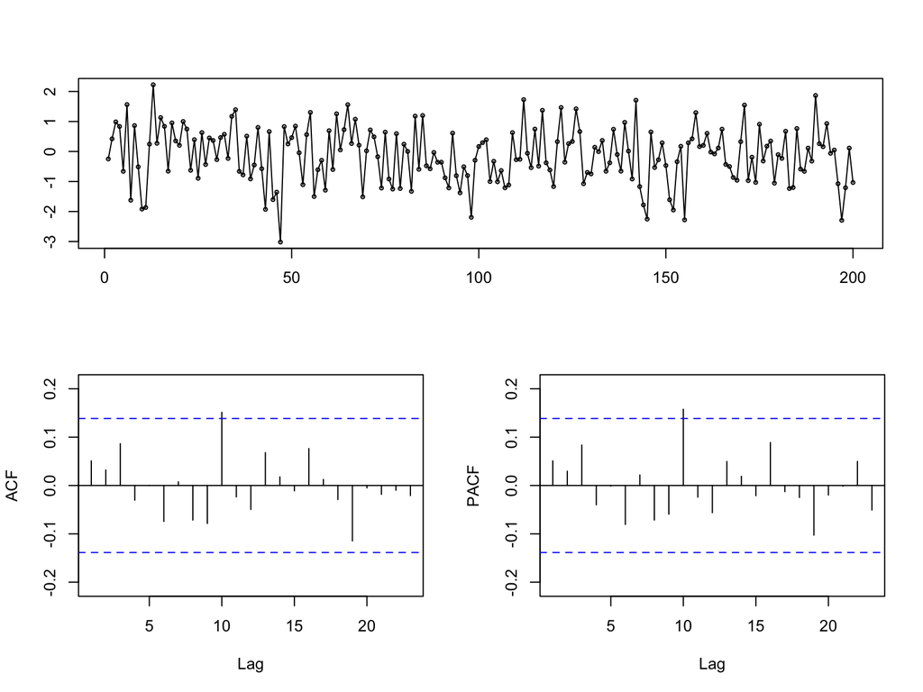

# Случайное блуждание (нестационарный процесс!)

Случайное блуждание, $y_t=y_{t-1}+\e_t$. Истинные $\rho_k$ и $\phi_k$ НЕ существуют!

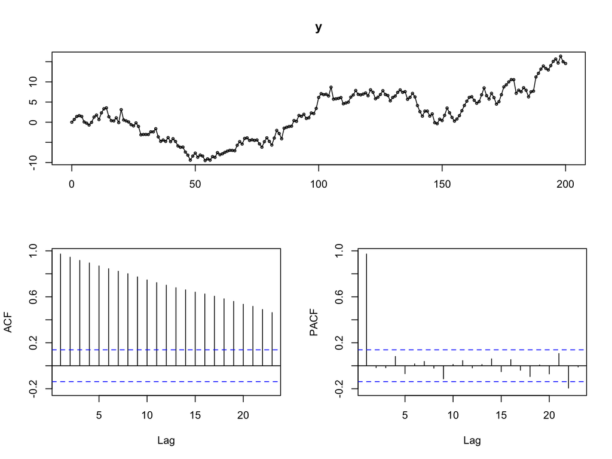

# Процесс с трендом (нестационарный процесс!)

Процесс с трендом, $y_t=0.02\cdot t +\varepsilon_t$. Истинные $\rho_k$ и $\phi_k$ НЕ существуют!

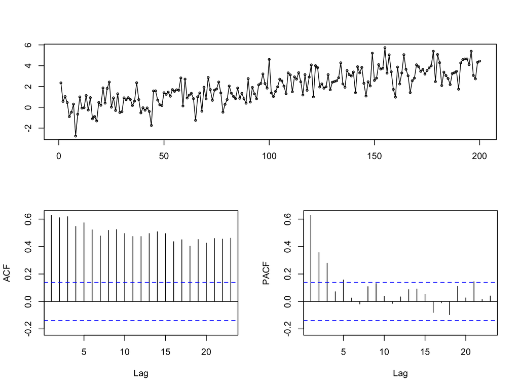

# AR(1)

AR(1), $y_t=0.7y_{t-1} +\varepsilon_t$

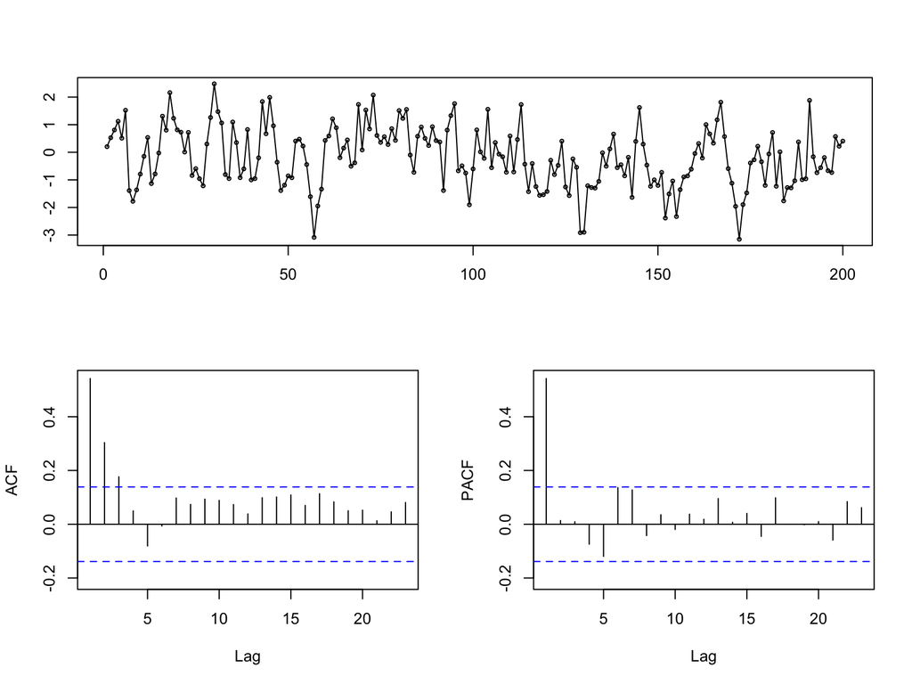

# AR(2)

AR(2), $y_t=0.9y_{t-1}-0.5y_{t-2} +\varepsilon_t$

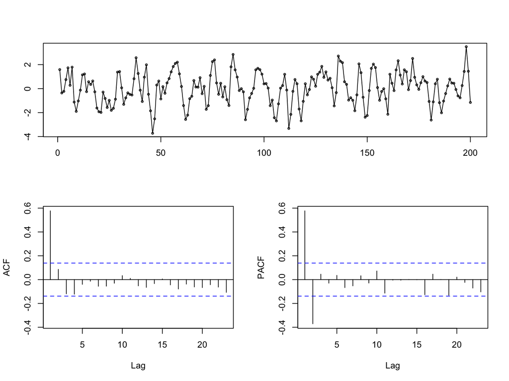

# MA(1)

MA(1), $y_t=0.7\varepsilon_{t-1} +\varepsilon_t$

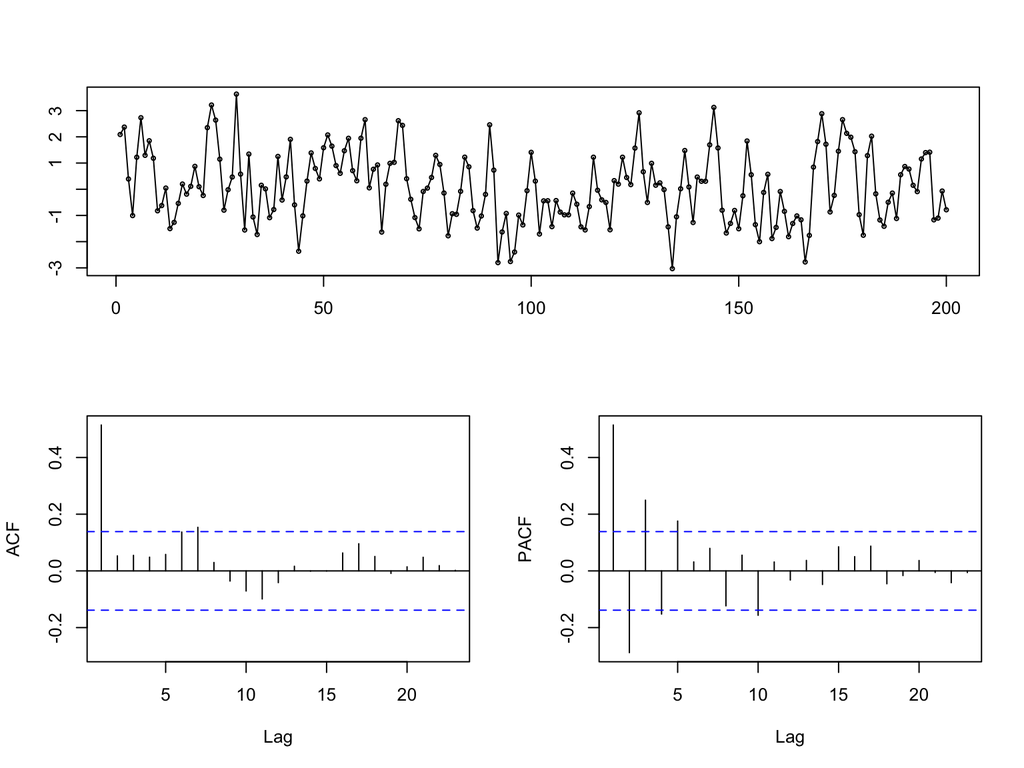

# MA(2)

MA(2), $y_t=0.9\varepsilon_{t-1} +0.5\varepsilon_{t-1}+\varepsilon_t$

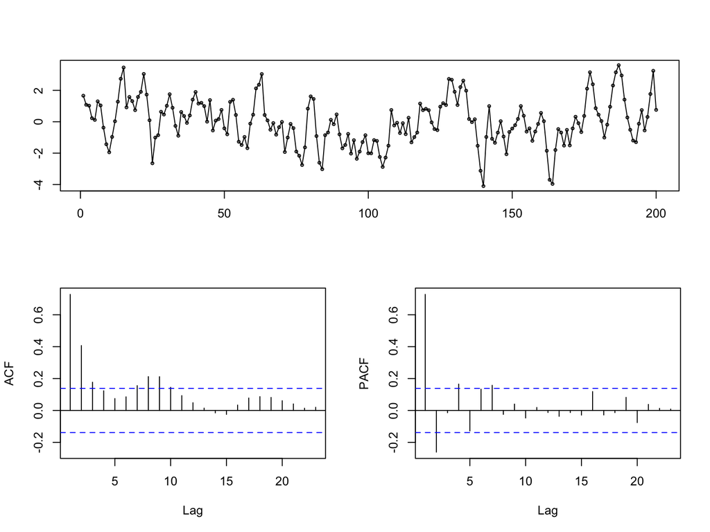

# ARMA(1,1)

ARMA(1,1), $y_t=0.7y_{t-1}+0.5\varepsilon_{t-1} +\varepsilon_t$

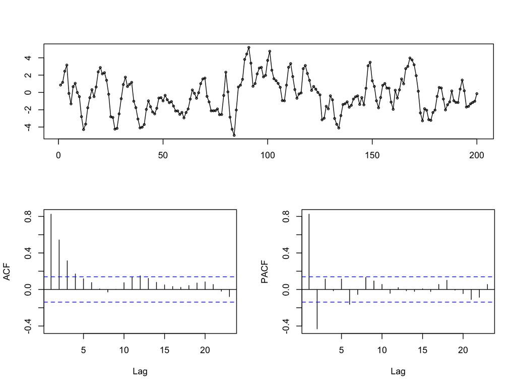

# Мораль

- Временные ряды: стационарные и нет
- Для стационарных — модель ARMA